# Edible Oil Price Analysis

2024-02-06

[figure not shown]

Go back to the main page

## Edible Oil Price Analysis

Data source: https://www.kaggle.com/datasets/chinmayshanbhag/historical-price-data-of-8-edible-oils-commodity

```r
library(tidyverse)
library(lubridate)
library(kableExtra)
```

Format tables:

```r
formatted_table <- function(df){
  kbl(df) %>%
  kable_styling(bootstrap_options = c("striped", "hover", "responsive"))
}
```

Load the data:

```r
file_name <- "./8 Edible Oils.csv"
df <- read_csv(file_name, show_col_types = FALSE)
formatted_table(head(df))
```

Month

Coconut Oil Price

Coconut Oil Price Change

Olive Oil Price

Olive Oil Price Change

Palm Kernel Oil Price

Palm Kernel Oil Price Change

Palm Oil Price

Palm Oil Price Change

Peanut Oil Price

Peanut Oil Price Change

Rapeseed Oil Price

Rapeseed Oil Price Change

Soybean Oil Price

Soybean Oil Price Change

Sunflower Oil Price

Sunflower Oil Price Change

Aug 1992

494

3490.25

NA

NA

382

600

NA

NA

409

NA

NA

Sep 1992

501

1.42%

3342.78

-4.23%

NA

NA

391

2.36%

562

-6.33%

NA

NA

421

2.93%

NA

NA

Oct 1992

493

-1.60%

2986.24

-10.67%

NA

NA

396

1.28%

565

0.53%

NA

NA

418

-0.71%

NA

NA

Nov 1992

496

0.61%

2747.90

-7.98%

NA

NA

413

4.29%

575

1.77%

NA

NA

437

4.55%

NA

NA

Dec 1992

461

-7.06%

2793.15

1.65%

NA

NA

401

-2.91%

622

8.17%

NA

NA

436

-0.23%

NA

NA

Jan 1993

444

-3.69%

2757.83

-1.26%

NA

NA

410

2.24%

621

-0.16%

NA

NA

444

1.83%

NA

NA

Transform dates:

```r
df <- df %>%
  mutate(Month = my(Month))
formatted_table(head(df))
```

Month

Coconut Oil Price

Coconut Oil Price Change

Olive Oil Price

Olive Oil Price Change

Palm Kernel Oil Price

Palm Kernel Oil Price Change

Palm Oil Price

Palm Oil Price Change

Peanut Oil Price

Peanut Oil Price Change

Rapeseed Oil Price

Rapeseed Oil Price Change

Soybean Oil Price

Soybean Oil Price Change

Sunflower Oil Price

Sunflower Oil Price Change

1992-08-01

494

3490.25

NA

NA

382

600

NA

NA

409

NA

NA

1992-09-01

501

1.42%

3342.78

-4.23%

NA

NA

391

2.36%

562

-6.33%

NA

NA

421

2.93%

NA

NA

1992-10-01

493

-1.60%

2986.24

-10.67%

NA

NA

396

1.28%

565

0.53%

NA

NA

418

-0.71%

NA

NA

1992-11-01

496

0.61%

2747.90

-7.98%

NA

NA

413

4.29%

575

1.77%

NA

NA

437

4.55%

NA

NA

1992-12-01

461

-7.06%

2793.15

1.65%

NA

NA

401

-2.91%

622

8.17%

NA

NA

436

-0.23%

NA

NA

1993-01-01

444

-3.69%

2757.83

-1.26%

NA

NA

410

2.24%

621

-0.16%

NA

NA

444

1.83%

NA

NA

Make the data tidy:

```r
tidy_df <- df %>%
  gather(`Coconut Oil Price`, `Olive Oil Price`, `Palm Kernel Oil Price`, `Palm Oil Price`, `Peanut Oil Price`, `Rapeseed Oil Price`, `Soybean Oil Price`, `Sunflower Oil Price`, key = "Oil Type", value = "Price")
formatted_table(head(tidy_df))
```

Month

Coconut Oil Price Change

Olive Oil Price Change

Palm Kernel Oil Price Change

Palm Oil Price Change

Peanut Oil Price Change

Rapeseed Oil Price Change

Soybean Oil Price Change

Sunflower Oil Price Change

Oil Type

Price

1992-08-01

NA

NA

NA

Coconut Oil Price

494

1992-09-01

1.42%

-4.23%

NA

2.36%

-6.33%

NA

2.93%

NA

Coconut Oil Price

501

1992-10-01

-1.60%

-10.67%

NA

1.28%

0.53%

NA

-0.71%

NA

Coconut Oil Price

493

1992-11-01

0.61%

-7.98%

NA

4.29%

1.77%

NA

4.55%

NA

Coconut Oil Price

496

1992-12-01

-7.06%

1.65%

NA

-2.91%

8.17%

NA

-0.23%

NA

Coconut Oil Price

461

1993-01-01

-3.69%

-1.26%

NA

2.24%

-0.16%

NA

1.83%

NA

Coconut Oil Price

444

Plot:

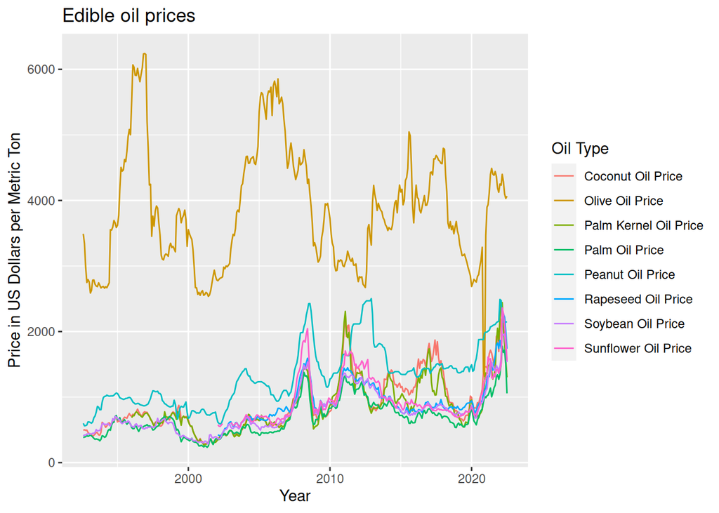

```r
p <- ggplot(data= tidy_df, aes(x = Month, y = `Price`)) +
  geom_line(aes(color = `Oil Type`)) +
  labs(title="Edible oil prices") +
  ylab("Price in US Dollars per Metric Ton") +
  xlab("Year")
p
```

Just Sunflower Oil:

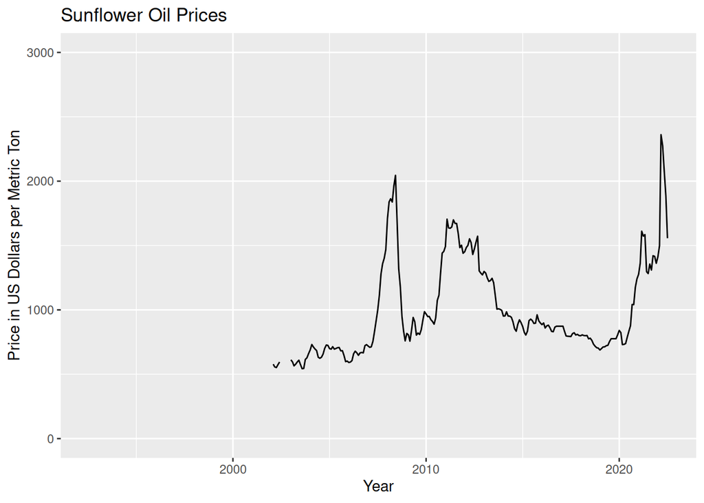

```r
p <- ggplot(data= df, aes(x = Month, y = `Sunflower Oil Price`)) +
  geom_line() +
  labs(title="Sunflower Oil Prices") +
  ylab("Price in US Dollars per Metric Ton") +
  xlab("Year") +
  ylim(c(0, 3000))
p
```

The End